# Analysing impact of different weather events

Aleksey Linetskiy

Tuesday, March 17, 2015

# Analysing impact of different weather events

## Synopsis

The study examines data from NOAA storm database in order to identify weather events that are most harmful to population or have greatest economy effect. The analysis checks three different definitions of the most harmful events: the events with historically maximal damage, events with maximal average damage and events with highest cumulative total damage. After comparing the lists obtained by analysing data according to each definition, the author comes to a conclusion about which of the events turn out to be the most dangerous.

## Data Processing

The research is based on the data from the NOAA storm database. Before being used for the analysis, the data was preprocessed and cleaned.

For the purpose of this research, the total damage done by the weather event will be calculated as a sum of property damage and crop damage; the total physical harm will be calculated as a sum of fatalities and injuries.

```r
library(knitr)

download.file(url='http://d396qusza40orc.cloudfront.net/repdata%2Fdata%2FStormData.csv.bz2', destfile="data/StormData.bz2", mode='wb')
data <- read.csv(bzfile('data/StormData.bz2'), as.is=c(2))
data2 <- data[,c('EVTYPE','BGN_DATE','FATALITIES', 'INJURIES', 'PROPDMG', 'PROPDMGEXP', 'CROPDMG', 'CROPDMGEXP')]
data2$propDmgMultiplier = 1
data2[data2$PROPDMGEXP=='K', 'propDmgMultiplier'] = 1000
data2[data2$PROPDMGEXP=='M', 'propDmgMultiplier'] = 1000000
data2$cropDmgMultiplier = 1
data2[data2$CROPDMGEXP=='K', 'cropDmgMultiplier'] = 1000
data2[data2$CROPDMGEXP=='M', 'cropDmgMultiplier'] = 1000000
data2$TotalDmg <- data2$PROPDMG*data2$propDmgMultiplier + data2$CROPDMG*data2$cropDmgMultiplier
data2$BGN_DATE <- as.Date(data2$BGN_DATE, "%m/%d/%Y %H:%M:%S")
data2$year = as.numeric(format(data2$BGN_DATE, "%Y"))
data2$EVTSTR = as.character(data2$EVTYPE)
data2$TotalHarm <- data2$FATALITIES+data2$INJURIES
```

The main problem with the raw data from NOAA database is the lack of uniformity in event types. There are many variations of the same event name, as well as some records which do not belong to any weather event. In order to clean the data, the event names will be matched to the ones from the list provided by the National Weather Service in the Storm Data Documentation. The events for which there is no match are converted to the “OTHER” category.

```r
eventNames <- data.frame(oldNames = unique(data2$EVTSTR), newNames = "", stringsAsFactors = FALSE)
eventNames[grepl("LOW TIDE", eventNames$oldNames , ignore.case = TRUE, perl=TRUE) & eventNames$newNames == "", 'newNames'] <- "ASTRONOMICAL LOW TIDE"
eventNames[grep("AVALANC", eventNames[eventNames$newNames=="",'oldNames'], ignore.case = TRUE, perl=TRUE),'newNames'] <- "AVALANCHE"
eventNames[grepl("BLIZZARD", eventNames$oldNames , ignore.case = TRUE, perl = TRUE) & eventNames$newNames == "",'newNames'] <- "BLIZZARD"
eventNames[grepl("COASTAL[\\s]+FLOOD", eventNames$oldNames , ignore.case = TRUE, perl=TRUE) & eventNames$newNames == "",'newNames'] <- "COASTAL FLOOD"
eventNames[grepl("COLD|CHILL", eventNames$oldNames , ignore.case = TRUE, perl=TRUE) & eventNames$newNames == "",'newNames'] <- "COLD/WIND CHILL"
eventNames[grepl("SLIDE", eventNames$oldNames , ignore.case = TRUE, perl=TRUE) & eventNames$newNames == "",'newNames'] <- "DEBRIS FLOW"
eventNames[grepl("FOG", eventNames$oldNames , ignore.case = TRUE, perl=TRUE) & eventNames$newNames == "",'newNames'] <- "DENSE FOG"
eventNames[grepl("SMOKE", eventNames$oldNames , ignore.case = TRUE, perl=TRUE) & eventNames$newNames == "",'newNames'] <- "DENSE SMOKE"
eventNames[grepl("DROUGHT", eventNames$oldNames , ignore.case = TRUE, perl=TRUE) & eventNames$newNames == "",'newNames'] <- "DROUGHT"
eventNames[grepl("DEV[I,E]L", eventNames$oldNames , ignore.case = TRUE, perl=TRUE) & eventNames$newNames == "",'newNames'] <- "DUST DEVIL"
eventNames[grepl("DUST", eventNames$oldNames , ignore.case = TRUE, perl=TRUE) & eventNames$newNames == "",'newNames'] <- "DUST STORM"
eventNames[grepl("HEAT", eventNames$oldNames , ignore.case = TRUE, perl=TRUE) & eventNames$newNames == "",'newNames'] <- "EXCESSIVE HEAT"
eventNames[grepl("FLASH", eventNames$oldNames , ignore.case = TRUE, perl=TRUE) & eventNames$newNames == "", 'newNames'] <- "FLASH FLOOD"
eventNames[grepl("LAKE.+FLOOD", eventNames$oldNames , ignore.case = TRUE, perl=TRUE) & eventNames$newNames == "", 'newNames'] <- "LAKESHORE FLOOD"
eventNames[grepl("FLOOD", eventNames$oldNames , ignore.case = TRUE, perl=TRUE) & eventNames$newNames == "", 'newNames'] <- "FLOOD"
eventNames[grepl("FROST|FREEZE", eventNames$oldNames , ignore.case = TRUE, perl=TRUE) & eventNames$newNames == "", 'newNames'] <- "FROST/FREEZE"
eventNames[grepl("CLOUD", eventNames$oldNames , ignore.case = TRUE, perl=TRUE) & eventNames$newNames == "", 'newNames'] <- "FUNNEL CLOUD"
eventNames[grepl("MARINE HAIL", eventNames$oldNames , ignore.case = TRUE, perl=TRUE) & eventNames$newNames == "", 'newNames'] <- "MARINE HAIL"
eventNames[grepl("MARINE HIGH", eventNames$oldNames , ignore.case = TRUE, perl=TRUE) & eventNames$newNames == "", 'newNames'] <- "MARINE HIGH WIND"
eventNames[grepl("MARINE STRONG", eventNames$oldNames , ignore.case = TRUE, perl=TRUE) & eventNames$newNames == "", 'newNames'] <- "MARINE STRONG WIND"
eventNames[grepl("MARINE T.+WIND", eventNames$oldNames , ignore.case = TRUE, perl=TRUE) & eventNames$newNames == "", 'newNames'] <- "MARINE THUNDERSTORM WIND"
eventNames[grepl("HAIL", eventNames$oldNames , ignore.case = TRUE, perl=TRUE) & eventNames$newNames == "", 'newNames'] <- "HAIL"
eventNames[grepl("HIGH[\\s]*TEMP|WARM", eventNames$oldNames , ignore.case = TRUE, perl=TRUE) & eventNames$newNames == "", 'newNames'] <- "HEAT"
eventNames[grepl("HEAVY[\\s]+RAIN", eventNames$oldNames , ignore.case = TRUE, perl=TRUE) & eventNames$newNames == "", 'newNames'] <- "HEAVY RAIN"
eventNames[grepl("HEAVY[\\s]+SNOW", eventNames$oldNames , ignore.case = TRUE, perl=TRUE) & eventNames$newNames == "", 'newNames'] <- "HEAVY SNOW"
eventNames[grepl("SURF", eventNames$oldNames , ignore.case = TRUE, perl=TRUE) & eventNames$newNames == "", 'newNames'] <- "HIGH SURF"
eventNames[grepl("HIGH[\\s]+WIND", eventNames$oldNames , ignore.case = TRUE, perl=TRUE) & eventNames$newNames == "", 'newNames'] <- "HIGH WIND"
eventNames[grepl("HURRI|TYPH", eventNames$oldNames , ignore.case = TRUE, perl=TRUE) & eventNames$newNames == "",'newNames' ] <- "HURRICANE/TYPHOON"
eventNames[grepl("ICE[\\s]+STORM", eventNames$oldNames , ignore.case = TRUE, perl=TRUE) & eventNames$newNames == "", 'newNames' ] <- "ICE STORM"
eventNames[grepl("LAK.+EFF", eventNames$oldNames , ignore.case = TRUE, perl=TRUE) & eventNames$newNames == "", 'newNames'] <- "LAKE-EFFECT SNOW"
eventNames[grepl("LIGHTN|LIGHTING|LIGNTNING", eventNames$oldNames , ignore.case = TRUE, perl=TRUE) & eventNames$newNames == "", 'newNames'] <- "LIGHTNING"
eventNames[grepl("RIP", eventNames$oldNames , ignore.case = TRUE, perl=TRUE) & eventNames$newNames == "", 'newNames'] <- "RIP CURRENT"
eventNames[grepl("SLEET", eventNames$oldNames , ignore.case = TRUE, perl=TRUE) & eventNames$newNames == "", 'newNames'] <- "SLEET"
eventNames[grepl("SURGE|TIDE", eventNames$oldNames , ignore.case = TRUE, perl=TRUE) & eventNames$newNames == "", 'newNames'] <- "STORM SURGE/TIDE"
eventNames[grepl("STRONG[\\s]+WIND", eventNames$oldNames , ignore.case = TRUE, perl=TRUE) & eventNames$newNames == "", 'newNames'] <- "STRONG WIND"
eventNames[grepl("THUN|TUNDER|TSTM|THUDER", eventNames$oldNames , ignore.case = TRUE, perl=TRUE) & eventNames$newNames == "", 'newNames'] <- "THUNDERSTORM WIND"
eventNames[grepl("TORNADO|LANDSPOUT|WHIRLWIND|TORNDAO", eventNames$oldNames , ignore.case = TRUE, perl=TRUE) & eventNames$newNames == "", 'newNames'] <- "TORNADO"
eventNames[grepl("TROPICAL[\\s]+DEPR", eventNames$oldNames , ignore.case = TRUE, perl=TRUE) & eventNames$newNames == "", 'newNames'] <- "TROPICAL DEPRESSION"
eventNames[grepl("TROPICAL[\\s]+STORM", eventNames$oldNames , ignore.case = TRUE, perl=TRUE) & eventNames$newNames == "", 'newNames'] <- "TROPICAL STORM"
eventNames[grepl("TSUNAMI", eventNames$oldNames , ignore.case = TRUE, perl=TRUE) & eventNames$newNames == "", 'newNames'] <- "TSUNAMI"
eventNames[grepl("VOLC", eventNames$oldNames , ignore.case = TRUE, perl=TRUE) & eventNames$newNames == "", 'newNames'] <- "VOLCANIC ASH"
eventNames[grepl("SPOUT", eventNames$oldNames , ignore.case = TRUE, perl=TRUE) & eventNames$newNames == "", 'newNames']  <- "WATERSPOUT"
eventNames[grepl("FIRE", eventNames$oldNames , ignore.case = TRUE, perl=TRUE) & eventNames$newNames == "", 'newNames'] <- "WILDFIRE"
eventNames[grepl("WINTER[\\s]*STORM|SNOWSTORM", eventNames$oldNames , ignore.case = TRUE, perl=TRUE) & eventNames$newNames == "", 'newNames']  <- "WINTER STORM"
eventNames[grepl("WINTER[\\s]*WEATHER|SNOW|ICE|ICY|COOL", eventNames$oldNames , ignore.case = TRUE, perl=TRUE) & eventNames$newNames == "", 'newNames'] <- "WINTER WEATHER"

# leftovers
eventNames[grepl("WIND|WND", eventNames$oldNames , ignore.case = TRUE, perl=TRUE) & eventNames$newNames == "", 'newNames'] <- "STRONG WIND"
eventNames[grepl("WINTRY|FREEZ|LOW[\\s]*TEM|WINTER", eventNames$oldNames , ignore.case = TRUE, perl=TRUE) & eventNames$newNames == "", 'newNames'] <- "WINTER WEATHER"
eventNames[grepl("HOT|RECORD[\\s]+TEMP", eventNames$oldNames , ignore.case = TRUE, perl=TRUE) & eventNames$newNames == "", 'newNames'] <- "HEAT"
eventNames[grepl("BURST", eventNames$oldNames , ignore.case = TRUE, perl=TRUE) & eventNames$newNames == "",'newNames'] <- "HIGH WIND"
eventNames[grepl("DROUGHT|DRY|DRIEST|LOW[\\s]*RAINFALL|BELOW[\\s]*NORMAL[\\s]*PRECIP", eventNames$oldNames , ignore.case = TRUE, perl=TRUE) & eventNames$newNames == "",'newNames'] <- "DROUGHT"
eventNames[grepl("WET|RAIN|PRECIP|SHOWER", eventNames$oldNames , ignore.case = TRUE, perl=TRUE) & eventNames$newNames == "",'newNames'] <- "HEAVY RAIN"
#All that was not recognized goes into "OTHER" category
eventNames[eventNames$newNames == "", 'newNames'] <- "OTHER"
cleanData <- merge(x=data2, y=eventNames, by.x ="EVTSTR", by.y="oldNames")
```

After the events are unified, it becomes noticeable that most of the events are not reported until 1993. (Before that year, only 3 different events are reported.) Because of that, the data before 1993 is discarded.

```r
eventTypesByYear <- aggregate (data=cleanData, newNames ~ year, function (x) length(unique(x)))
print(eventTypesByYear)
```

```
##    year newNames
## 1  1950        1
## 2  1951        1
## 3  1952        1
## 4  1953        1
## 5  1954        1
## 6  1955        3
## 7  1956        3
## 8  1957        3
## 9  1958        3
## 10 1959        3
## 11 1960        3
## 12 1961        3
## 13 1962        3
## 14 1963        3
```

[output cut: 48 more lines]

```r
cleanDataCut <- cleanData[cleanData$year>=1993,]
```

## Analysis

The question “Which weather event is the most dangerous” can be answered in several different ways. First, one can consider the events which hold the record of the damage and population harm. Then, there is a question of which events on average bring the most harm and damage. And, lastly, the cumulative damage from the events of different types can be compared in order to find out which type of the events is responsible for the greatest havoc overall.

### Maximal damage

```r
library(knitr)
maxDamage <- aggregate(TotalDmg ~ newNames, cleanDataCut, max)
maxDamage <- maxDamage[order(-maxDamage$TotalDmg),]
kable(head(maxDamage,5)[,c(1,2)],col.names=c("Event", "Damage"), caption="5 events with the highest damage since 1993")
```

5 events with the highest damage since 1993

|  | Event | Damage |
| --- | --- | --- |
| 22 | HIGH WIND | 1104000000 |
| 14 | FLOOD | 950000000 |
| 17 | HAIL | 900000000 |
| 23 | HURRICANE/TYPHOON | 824220000 |
| 37 | THUNDERSTORM WIND | 750000000 |

```r
maxHarm <- aggregate(TotalHarm ~ newNames, cleanDataCut, max)
maxHarm <- maxHarm[order(-maxHarm$TotalHarm),]
kable(head(maxHarm,5)[,c(1,2)], col.names=c("Event", "Deaths and injuries"), caption="5 events with the highest population harm since 1993")
```

5 events with the highest population harm since 1993

|  | Event | Deaths and injuries |
| --- | --- | --- |
| 24 | ICE STORM | 1569 |
| 38 | TORNADO | 1308 |
| 14 | FLOOD | 802 |
| 23 | HURRICANE/TYPHOON | 787 |
| 12 | EXCESSIVE HEAT | 583 |

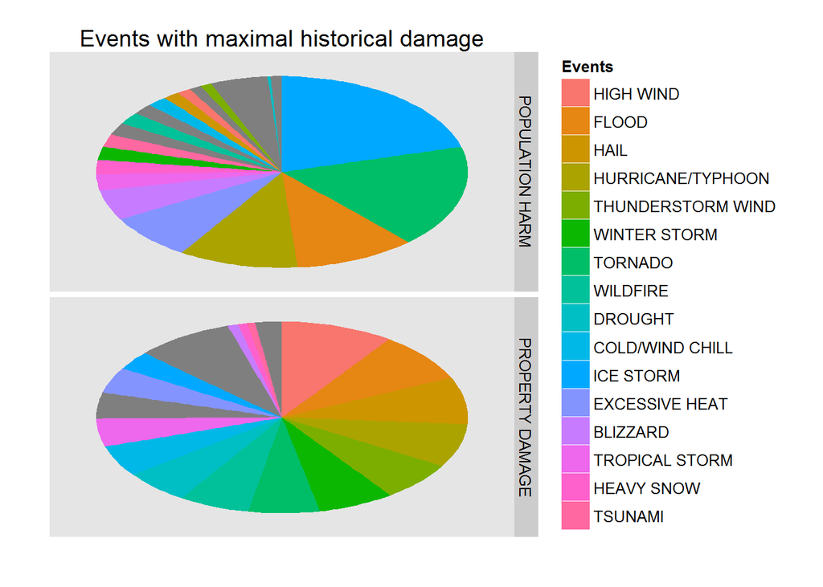

```r
maxDamage$StatType <- "PROPERTY DAMAGE"
maxHarm$StatType <- "POPULATION HARM"
names(maxDamage) <- c("event", "damage", "stat")
names(maxHarm) <- c("event", "damage", "stat")
maxStats <- rbind(maxDamage, maxHarm)
maxDamage.top10 <- head(maxDamage, 10)
maxHarm.top10 <- head(maxHarm, 10)
top10Events <- unique(c(maxDamage.top10$event, maxHarm.top10$event))

library(ggplot2)
g <- ggplot(data=maxStats, aes(x=factor(1), y=damage, fill=factor(event)))
g <- g+geom_bar(width=1,stat="identity")+xlab("")+ylab("")+ggtitle("Events with maximal historical damage")
g <- g+ facet_grid(facets=stat~., scale="free")
g <- g+coord_polar(theta="y")
g <- g+ scale_fill_hue(limits=top10Events, name="Events")
g <- g+ theme(axis.ticks = element_blank(), axis.text.y=element_blank(), axis.text.x=element_blank(), panel.grid.minor=element_blank(), panel.grid.major=element_blank())
print(g)
```

The tables show that the most damaging events were dealing with high winds (High Wind, Hurricane and Thunderstorm wind); Flood and Hail are also in the record table. In terms of the population damage, the record holders are ice storm and tornado, followed by flood, hurricane and heat. Quite predictably, hurricane turned out to be in the top 5 in both categories. The chart show the distribution of the damage between the top 10 events in both damage and population harm categories.

### Average Damage

```r
library(knitr)
avgDamage <- aggregate(TotalDmg ~ newNames, cleanDataCut, mean)
avgDamage <- avgDamage[order(-avgDamage$TotalDmg),]
kable(head(avgDamage,5)[,c(1,2)],col.names=c("Event", "Average Damage"), caption="5 events with the highest average damage since 1993")
```

5 events with the highest average damage since 1993

|  | Event | Average Damage |
| --- | --- | --- |
| 23 | HURRICANE/TYPHOON | 50075597 |
| 41 | TSUNAMI | 7204100 |
| 9 | DROUGHT | 5183638 |
| 40 | TROPICAL STORM | 4676164 |
| 35 | STORM SURGE/TIDE | 2732634 |

```r
avgHarm <- aggregate(TotalHarm ~ newNames, cleanDataCut, mean)
avgHarm <- avgHarm[order(-avgHarm$TotalHarm),]
kable(head(avgHarm,5)[,c(1,2)], col.names=c("Event", "Average Deaths and Injuries"), caption="5 events with the highest average population harm since 1993")
```

5 events with the highest average population harm since 1993

|  | Event | Average Deaths and Injuries |
| --- | --- | --- |
| 41 | TSUNAMI | 8.100000 |
| 23 | HURRICANE/TYPHOON | 4.919463 |
| 12 | EXCESSIVE HEAT | 4.690612 |
| 33 | RIP CURRENT | 1.422481 |
| 11 | DUST STORM | 1.054795 |

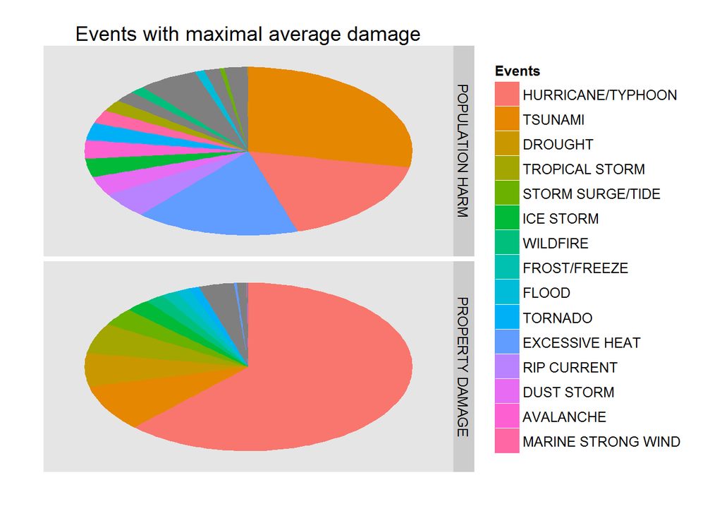

```r
avgDamage$StatType <- "PROPERTY DAMAGE"
avgHarm$StatType <- "POPULATION HARM"
names(avgDamage) <- c("event", "damage", "stat")
names(avgHarm) <- c("event", "damage", "stat")
avgStats <- rbind(avgDamage, avgHarm)
avgDamage.top10 <- head(avgDamage, 10)
avgHarm.top10 <- head(avgHarm, 10)
top10Events <- unique(c(avgDamage.top10$event, avgHarm.top10$event))

g <- ggplot(data=avgStats, aes(x=factor(1), y=damage, fill=factor(event)))
g <- g+geom_bar(width=1,stat="identity")+xlab("")+ylab("")+ggtitle("Events with maximal average damage")
g <- g+ facet_grid(facets=stat~., scale="free")+scale_fill_brewer(palette="Set1")
g <- g+coord_polar(theta="y")
g <- g+ scale_fill_hue(limits=top10Events, name="Events")
g <- g+ theme(axis.ticks = element_blank(), axis.text.y=element_blank(), axis.text.x=element_blank(), panel.grid.minor=element_blank(), panel.grid.major=element_blank())
print(g)
```

### Cumulative damage

```r
library(knitr)
cumDamage <- aggregate(TotalDmg ~ newNames, cleanDataCut, sum)
cumDamage <- cumDamage[order(-cumDamage$TotalDmg),]
kable(head(cumDamage,5)[,c(1,2)],col.names=c("Event", "Total Damage"), caption="5 events with the highest cumulative damage since 1993")
```

5 events with the highest cumulative damage since 1993

|  | Event | Total Damage |
| --- | --- | --- |
| 14 | FLOOD | 28529477768 |
| 38 | TORNADO | 21498380396 |
| 13 | FLASH FLOOD | 17440064348 |
| 17 | HAIL | 17328883370 |
| 23 | HURRICANE/TYPHOON | 14922527916 |

```r
cumHarm <- aggregate(TotalHarm ~ newNames, cleanDataCut, sum)
cumHarm <- cumHarm[order(-cumHarm$TotalHarm),]
kable(head(cumHarm,5)[,c(1,2)], col.names=c("Event", "Total Harm"), caption="5 events with the highest cumulative harm since 1993")
```

5 events with the highest cumulative harm since 1993

|  | Event | Total Harm |
| --- | --- | --- |
| 38 | TORNADO | 24996 |
| 12 | EXCESSIVE HEAT | 12341 |
| 14 | FLOOD | 7279 |
| 37 | THUNDERSTORM WIND | 6532 |
| 27 | LIGHTNING | 6049 |

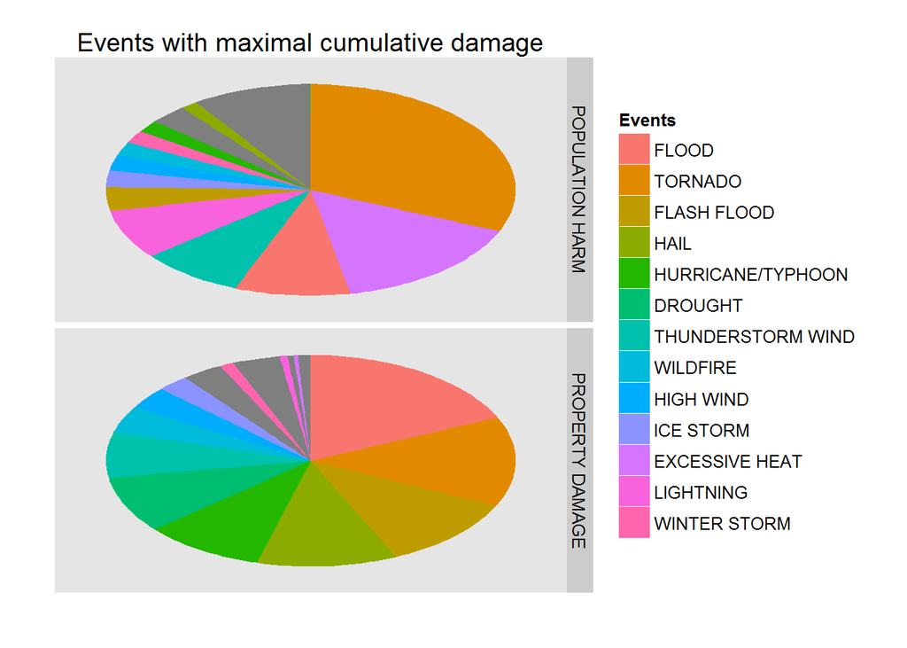

```r
cumDamage$StatType <- "PROPERTY DAMAGE"
cumHarm$StatType <- "POPULATION HARM"
names(cumDamage) <- c("event", "damage", "stat")
names(cumHarm) <- c("event", "damage", "stat")
cumStats <- rbind(cumDamage, cumHarm)
cumDamage.top10 <- head(cumDamage, 10)
cumHarm.top10 <- head(cumHarm, 10)
top10Events <- unique(c(cumDamage.top10$event, cumHarm.top10$event))

g <- ggplot(data=cumStats, aes(x=factor(1), y=damage, fill=factor(event)))
g <- g+geom_bar(width=1,stat="identity")+xlab("")+ylab("")+ggtitle("Events with maximal cumulative damage")
g <- g+ facet_grid(facets=stat~., scale="free")
g <- g+coord_polar(theta="y")+scale_fill_brewer(palette="Spectral")
g <- g+ scale_fill_hue(limits=top10Events, name="Events")
g <- g+ theme(axis.ticks = element_blank(), axis.text.y=element_blank(), axis.text.x=element_blank(), panel.grid.minor=element_blank(), panel.grid.major=element_blank())
print(g)
```

Cumulative damage is the total damage done by a certain event type in all years. As one can see, floods turn out to be the source of the most damage. Tornadoes are next in the list - but they hold the first place in terms of the damage to population. The chart show the distribution of the cumulative damage between the top 10 events in both damage and population harm categories.